The vignette presesented here describes how to prepare data for RF-SLAM and make use of the necessary packages to both train and evaluate an RF-SLAM model. For the purpose of the example, we will use the Mayo Clinic Primary Biliary Cirrhosis sequential data described here: https://stat.ethz.ch/R-manual/R-patched/library/survival/html/pbcseq.html.

The task we are trying to solve is to predict the death of a patient within the next 300 days at each time point.

To begin, let’s load some packages we will need for the data processing, as well as RF-SLAM itself.

To get the RFSLAM source code, run the following command:

```r
tryCatch(
  {find.package('rfSLAM')},
  error=function(e){remotes::install_github("mattrosen/RFSLAM")}
)
```

```
## [1] "C:/Users/matth/AppData/Local/R/win-library/4.2/rfSLAM"
```

Then, to get the forward facing functions which we will use in the vingette, run the following command:

```r
tryCatch(
  {find.package('rfslamtools')},
  error=function(e){remotes::install_github("matthewlrobinson/rfslamtools")}
)
```

```
## [1] "C:/Users/matth/AppData/Local/R/win-library/4.2/rfslamtools"
```

At this point, both RFSLAM packages should be installed and we can proceed to loading in the other necessary packages.

```r
library(ggRandomForests)
library(rfSLAM)
library(tidyverse)
library(grid)
library(gridExtra)
```

```r
library(ggsci)
library(rpart)
library(splines)
library(rpart.plot)
library(slider)
library(rfslamtools)
library(pROC)
library(caret)
```

Let’s load in the data. Additionally, we load a csv file which maps variables to their descriptions, called `var_key`. This is used for plotting feature importance later on.

```r
data(pbc, package="survival")
var_key <-read_csv("https://raw.githubusercontent.com/matthewlrobinson/rfslamtools/main/vignettes/var_key.csv") #example variable key
```

RF-SLAM currently only supports binary classification. Thus, we convert the labels here into ones where we have either a death or no death.

```r
pbcseq <- pbcseq %>%
  arrange(id, futime) %>%
  mutate(status = if_else(status == 2, 1, 0),
    next_id = lead(id),
    next_id = if_else(is.na(next_id),max(id),next_id),
    death = if_else(id != next_id & status == 1,1,0)) %>%
  select(-next_id)
```

RF-SLAM requires data to be in the format where there is one row per each patient’s CPIU. A CPIU is a person-time interval that has a length determine by the user based on what is clinically relevant. Here, we choose to use CPIU length’s of 100 days. To start, We need to figure out what the maximum time multiple of 100 days is for each patient.

```r
pbcseq$max_cpiu <- (plyr::round_any(pbcseq$futime, 100, f = floor) / 100) + 1
```

In our dataset, we do not have data that is exactly at each 100 days of treatment. Thus, we will need to create a bigger dataset and fill in the necessary gaps in order for RF-SLAM to function properly. Here, we calculate how big a dataframe we need based on the `max_cpiu` values just calculated.

```r
final_cpius <- pbcseq %>% group_by(id) %>% dplyr::summarise(`max(cpiu)` = max(max_cpiu))
nrows_needed <- sum(final_cpius$`max(cpiu)`)
```

Here we create the dataframe that extends out to as many cpius as needed, leaving the multiples of 100 blank.

```r
full_df <- as.data.frame(matrix(nrow = nrows_needed, ncol = 3))
colnames(full_df) <- c("id", "cpiu", "day")
count <- 0
for (i in 1:nrow(final_cpius)) {
  days <- 0
  curr_id <- final_cpius[i, "id"]
  for (j in 1:final_cpius[i, "max(cpiu)"]$'max(cpiu)') {
    full_df[count,] <- c(curr_id, j, days)
    days <- days + 100
    count <- count + 1
  }
}
```

Now let’s merge together our actual dataset and the blank one we made to create the final dataframe where we will still have a lot of NA values.

```r
pbc_tomerge <- pbcseq %>% select(-c(max_cpiu))
test <- full_df %>% full_join(pbc_tomerge, by = c("id", "day"))
test <- arrange(test, id, day)
```

fix this one weird issue (NOTE TO DANIEL: INVESTIGATE LATER)

```r
test[1, "cpiu"] <- 1
```

Now to fill in the blanks, we fill in the cpiu’s without any data using the most recent covariates. This means that if, for example, the covariates change at day 98, the cpiu starting at day 100 will be filled with the covariates from day 98. We achieve this by grouping by the `id` and then using the `fill` function.

```r
test <- test %>% dplyr::group_by(id) %>% fill(colnames(test), .direction = "down")
test <- data.frame(test)
test <- test[!is.na(test$day),]
```

To capture the fact that every interval is not exactly 100 days, RF-SLAM using risk-time values that tell us for what fraction of a full CPIU the current row pertains to. For example, if a row has a start day of 100 and the next row has a start day of 200, we know that this is a full CPIU and the risk time is 1.0. On the other hand, if a row starts at day 190 and the next row is at 200 days, the risk time is 0.1. Here, we create a column with the risk time values and clean up the data a bit.

```r
test <- test %>% mutate(next_day = lead(day))
test$next_day <- ifelse((test$next_day == 0) | is.na(test$next_day), test[,"futime"], test[,"next_day"])
test$risk_time <- (test$next_day - test$day) / 100
test <- test %>% select(-c(futime, next_day))
test <- test %>% mutate(next_id = lead(id), next_death = lead(death))
test[(test$next_id == test$id) & (test$death == 1), "death"] <- 0
test <- test %>% select(-c(next_death))
test$risk_time <- ifelse(test$risk_time == 0, 1, test$risk_time)
```

Now, one naive approach to modeling the task is to predict whether a patient will die based on the current row’s data. However, a more informative task is to create labels using look-ahead, and ask if a patient is going to die 300 days into the future. The code block below creates labels that do exactly that.

```r
create_labels <- function(df, x = 5) {
  labels <- unlist(slide_index(df$death, df$day, max, .after = 300))
  df$label <- labels
  return(df)
}
final_df <- data.frame(test %>% dplyr::group_by(id) %>% dplyr::group_modify(.f = create_labels))
```

Finally, let’s do some data cleaning to turn `sex` into a numeric value and create the extra `int.n` column that we need for the RF-SLAM functions.

```r
final_df$sex <- ifelse(final_df$sex == 'f', 1, 0)
final_df <- final_df %>% select(-c(next_id, death))
final_df$int.n <- final_df$cpiu
final_df <- filter(final_df, !duplicated(final_df[,c("id", "label")]) | label == 0) #ask about whether we should do this step or not
final_df$days_since_cpiu_start <- final_df$day - (final_df$cpiu - 1)*100
```

Let’s take a look at the output so we can pick a parameter set. Based on the table, we’d say that 100 trees, NULL nodedepth, and an nsplit value of 5 give the best results.

```r
best_params
```

```
##   n_trees nodedepth nsplit average auc across folds
## 1     100      NULL      5                0.8466670
## 2     200      NULL      5                0.8458310
## 3     100         3      5                0.8409594
## 4     200         3      5                0.8426328
## 5     100      NULL     10                0.8404179
## 6     200      NULL     10                0.8424917
## 7     100         3     10                0.8398263
## 8     200         3     10                0.8423112
```

Let’s train the final model using the optimal parameters and then look at feature importance, calibration, and an rpart summary tree. In addition, here we calibrate the final trained model using the `calibrate.model()` function.

```r
forest <- df %>%
  select(-all_of(drop)) %>%
  create_model("label", "pid", "risk_time", "int.n", "cpiu", ntree = 100, nodedepth = NULL, nsplit = 5)

df_with_predictions <- df %>%
  mutate(p.hat =
           calibrate.model(
              p.hat = forest$preds,
              rf.df.1 = df,
              target_varname = "label",
              time_varname = "cpiu")
)

analysis_vars <- df_with_predictions %>%
  select(-c(pid, status, label, risk_time, int.n)) %>%
  names()
```

### Feature Importance

The feature importance plot shows the percentage of trees each variable is present in in the random forest. The more trees the variable is in, the more often it is used for splitting when making predictions, and thus the more important it is. As we might expect, the top variables we see in the plot line up with the most important variables according to the rpart trees, such as the bilirunbin and edema values.

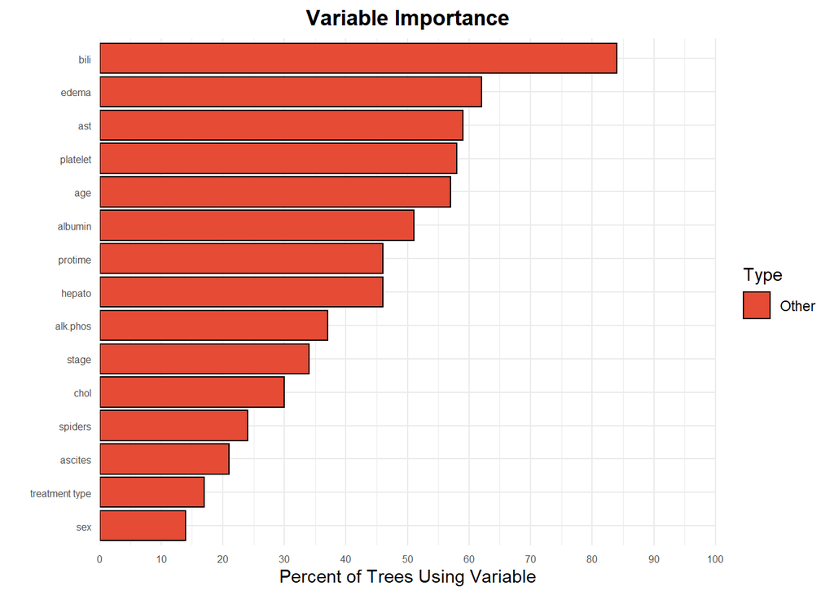

```r
feature_importance_plot(forest$model, var_key, importance_threshold = 10) #plot feature importance
```

### Rpart Tree The rpart tree is a summary representation of the random forest using a single tree. In particular, it is the result of training a regression tree on the outputted predicted probabilities. Then, we plot a visual representation of the tree so we can understand the predictions. This is a particularly useful technique for clinicians looking to understand their models.

Here, we can see that the bilirunbin value is most important since it is the top splitting variable. Then edema is second in importance, at the second level of the tree, after which the tree begins to get relatively more complicated.

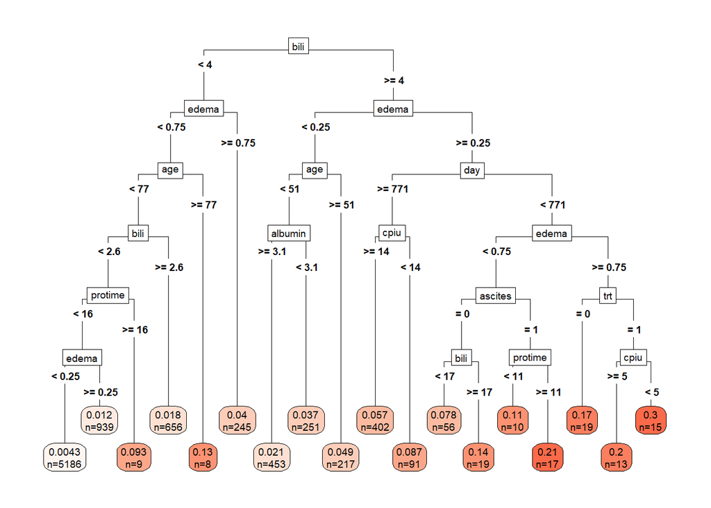

```r
rpart_summary(
   rf.df.1 = df_with_predictions,
   risk_col = 'p.hat',
   vars_list = analysis_vars
 )
```

If we want to hide the number of CPIUs in each node, we can do the following

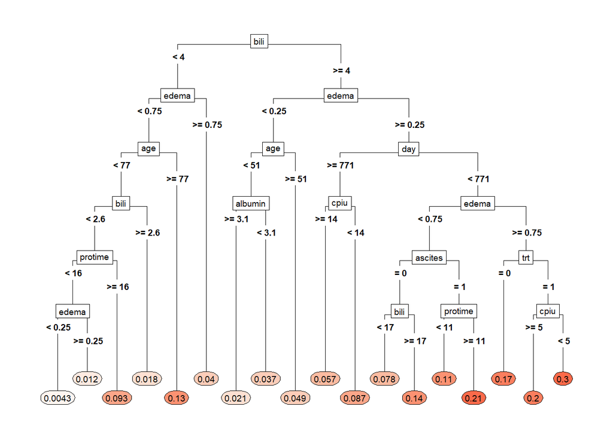

```r
rpart_summary(
   rf.df.1 = df_with_predictions,
   risk_col = 'p.hat',
   vars_list = analysis_vars,
   no_n =TRUE
 )
```

### Time varying AUC In a RF-SLAM model, the accuracy will be change depending on what time point is considered. This can be visualized using a time-varying AUC plot

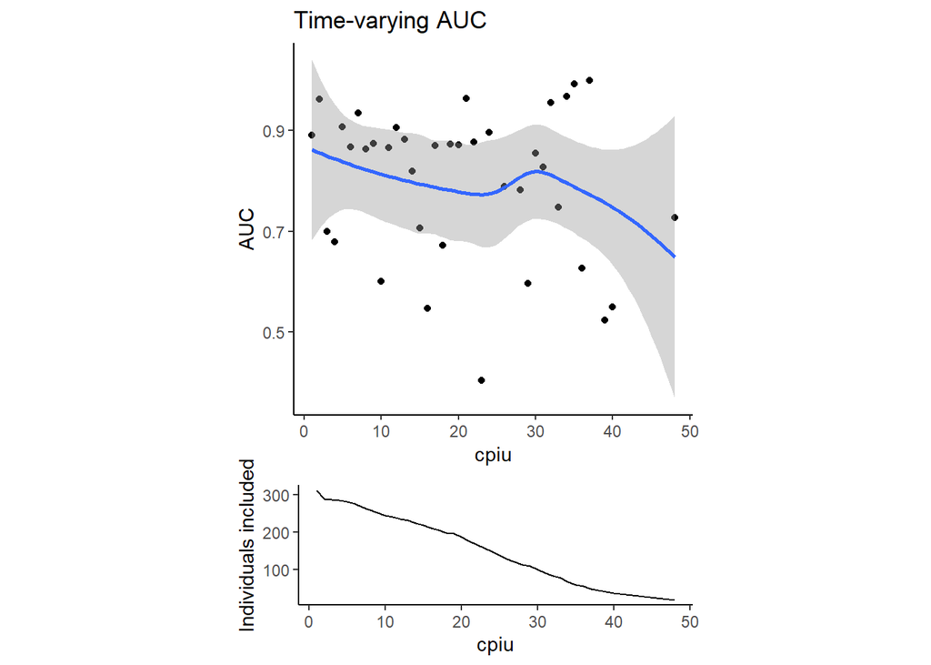

```r
plot_time_varying_auc(sca1.df = df_with_predictions,
       target = 'label',
       id_col = 'pid',
       patient_count_col =  'int.n',
       time_col = 'cpiu')
```

### AUC at a single point in time

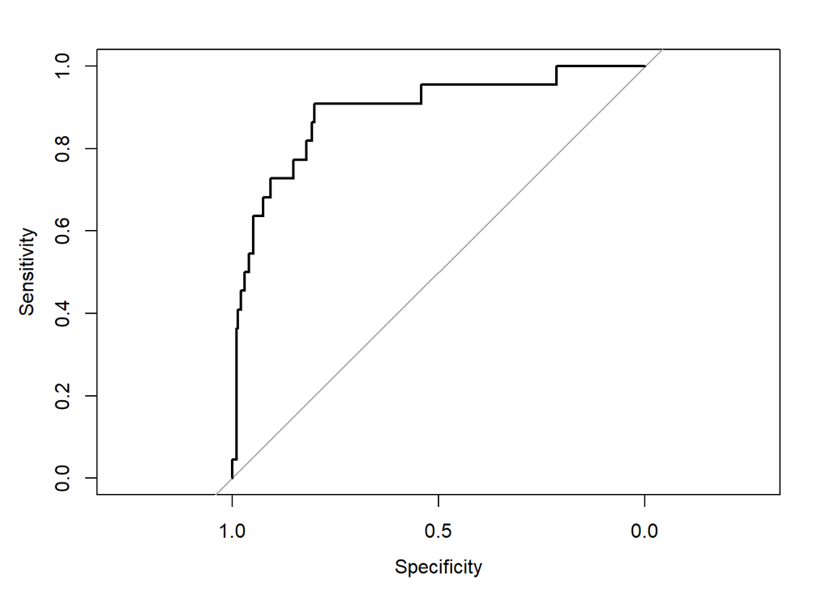

```
##
## Call:
## roc.default(response = d1$label, predictor = d1$p.hat, auc = TRUE,     plot = TRUE)
##
## Data: d1$p.hat in 290 controls (d1$label 0) < 22 cases (d1$label 1).
## Area under the curve: 0.8901
```

```r
d1 <- df_with_predictions %>% filter(cpiu == 1)
roc(d1$label,d1$p.hat, plot = TRUE, auc = TRUE)
```

## Dependence plots

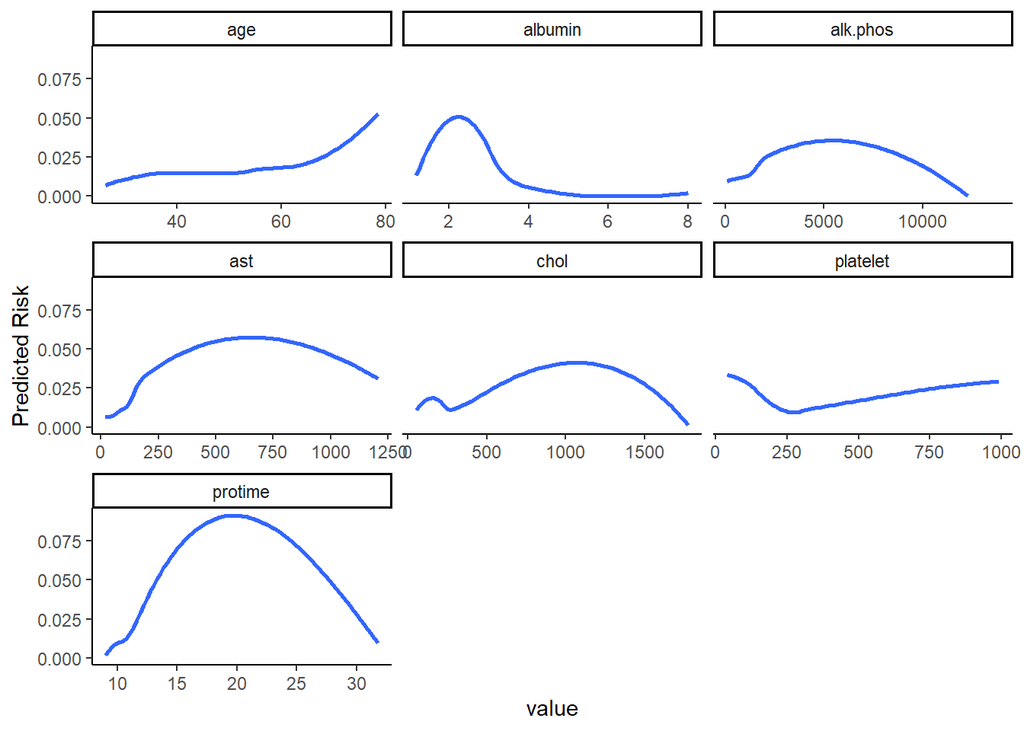

```r
df_with_predictions %>%
  select(all_of(analysis_vars)) %>%
  select_if(~is.numeric(.) & all(!(. %in% c(0,1)))) %>%
  pivot_longer(-p.hat) %>%
  ggplot(aes(x = value, y= p.hat)) +
  geom_smooth(se = FALSE, show.legend = FALSE, method = 'loess', formula = 'y ~ x') +
  ylab("Predicted Risk") + theme_classic() +
  facet_wrap(vars(name), scales = "free_x") +
  ylim(c(0,NA))
```

## Interpretation of Plots

### Calibration

The calibration plot shows the relationship between the predicted and observed event probabilities. In particular, a well calibrated model will be one where the values align and a straight line forms on the dotted line in the plot. Here, we see that there are times where we deviate and under predict the event probability, but overall this is satisfactory.

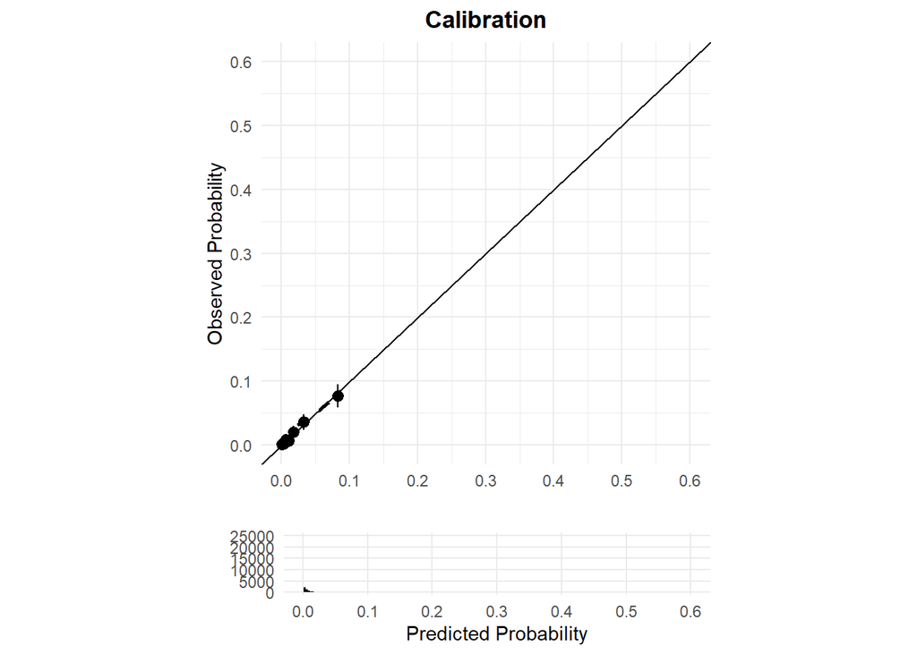

```r
calibration_plot(
  rf.df.1 = df_with_predictions,
  target = "label",
  risk_col = 'p.hat',
  vars_list = analysis_vars
)
```

Or use one function to display all relevant plots

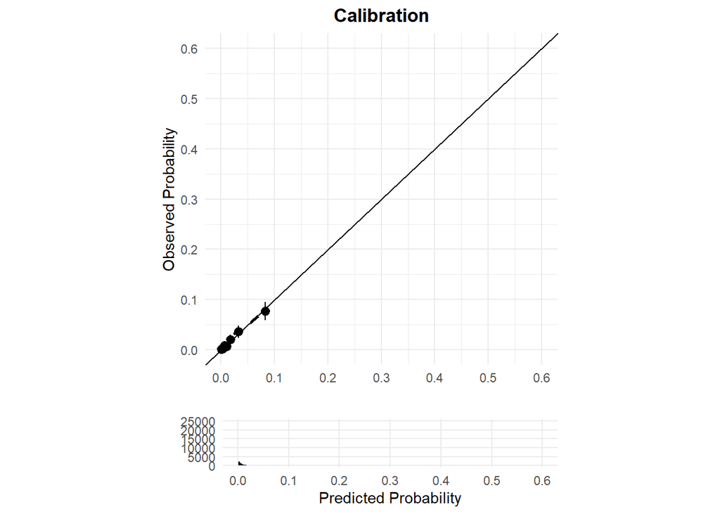

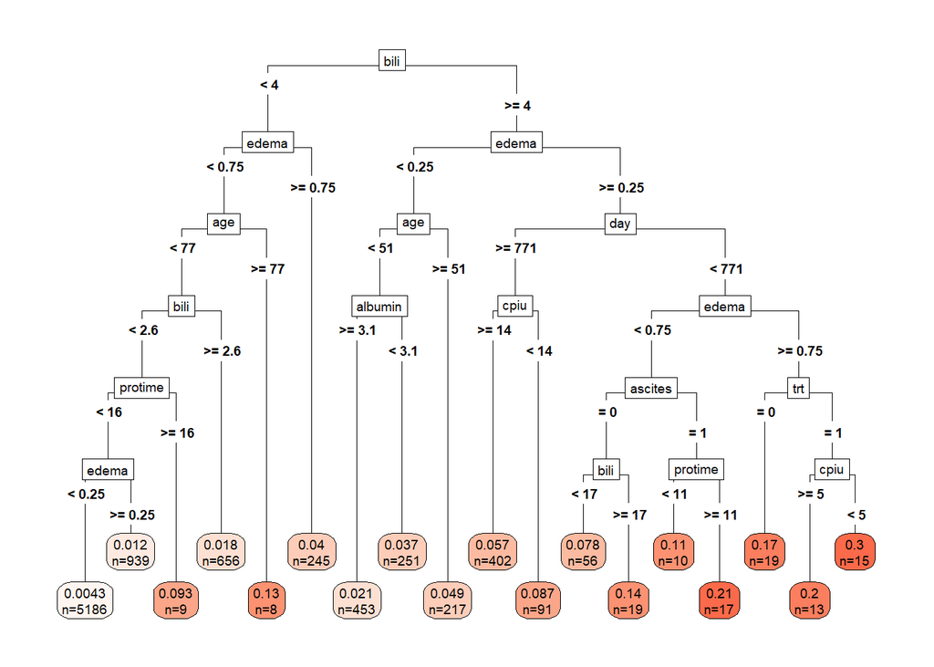

```r
analysis_plots(
  rf.df.1 = df_with_predictions,
  target = "label",
  risk_col = "p.hat",
  time_col = "cpiu",
  vars_list = analysis_vars
)
```